# Acoustic correlates of perceived prominence in German and Catalan: Bayesian Modeling

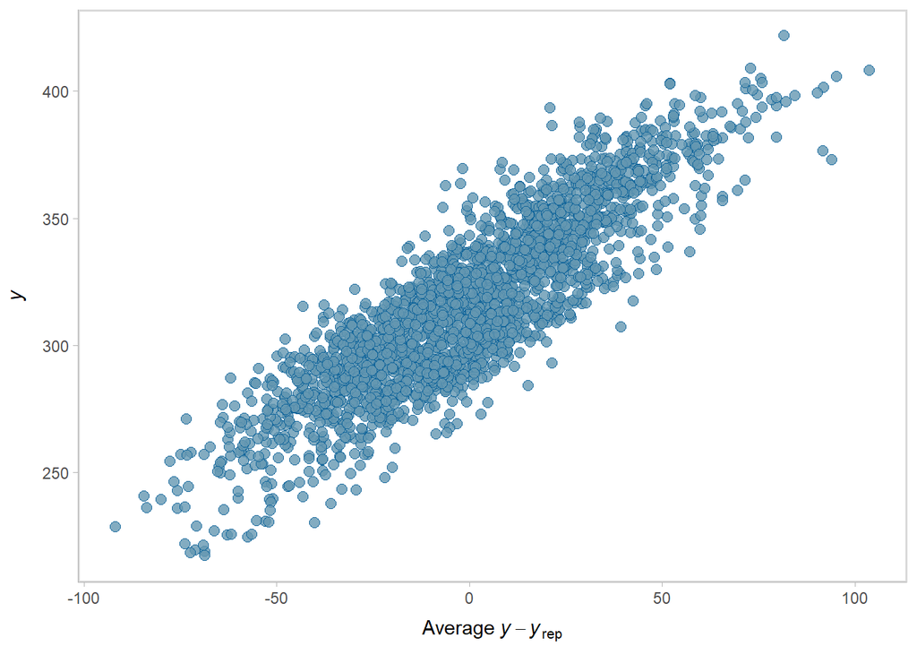

Extract samples.

| variable | mean | median | sd | mad | q5 | q95 | rhat | ess_bulk | ess_tail |
| --- | --- | --- | --- | --- | --- | --- | --- | --- | --- |
| b_percProm1 | 5.764350e+00 | 5.76426221 | 0.014198971 | 0.013790953 | 5.740838e+00 | 5.78767388 | 1.0018352 | 3826.511 | 5693.696 |
| b_percProm2 | 5.753245e+00 | 5.75327056 | 0.009315590 | 0.009141426 | 5.737865e+00 | 5.76875621 | 1.0010363 | 4176.618 | 7493.004 |
| b_percProm3 | 5.720235e+00 | 5.72034325 | 0.011292720 | 0.011146445 | 5.701505e+00 | 5.73859038 | 1.0005135 | 5958.935 | 8938.191 |
| b_gender_s | 8.452722e-03 | 0.00619065 | 0.007799715 | 0.006214241 | 4.781371e-04 | 0.02392774 | 0.9999196 | 10158.545 | 9555.091 |
| exp_b_percProm1 | 3.187639e+02 | 318.70381924 | 4.526310863 | 4.399511696 | 3.113251e+02 | 326.25323619 | 1.0018352 | 3826.511 | 5693.696 |
| exp_b_percProm2 | 3.152254e+02 | 315.21992225 | 2.936031693 | 2.879110792 | 3.104009e+02 | 320.13929967 | 1.0010363 | 4176.618 | 7493.004 |
| exp_b_percProm3 | 3.049960e+02 | 305.00959863 | 3.443795519 | 3.394222544 | 2.993177e+02 | 310.62623662 | 1.0005135 | 5958.935 | 8938.191 |

Check conditional effect.

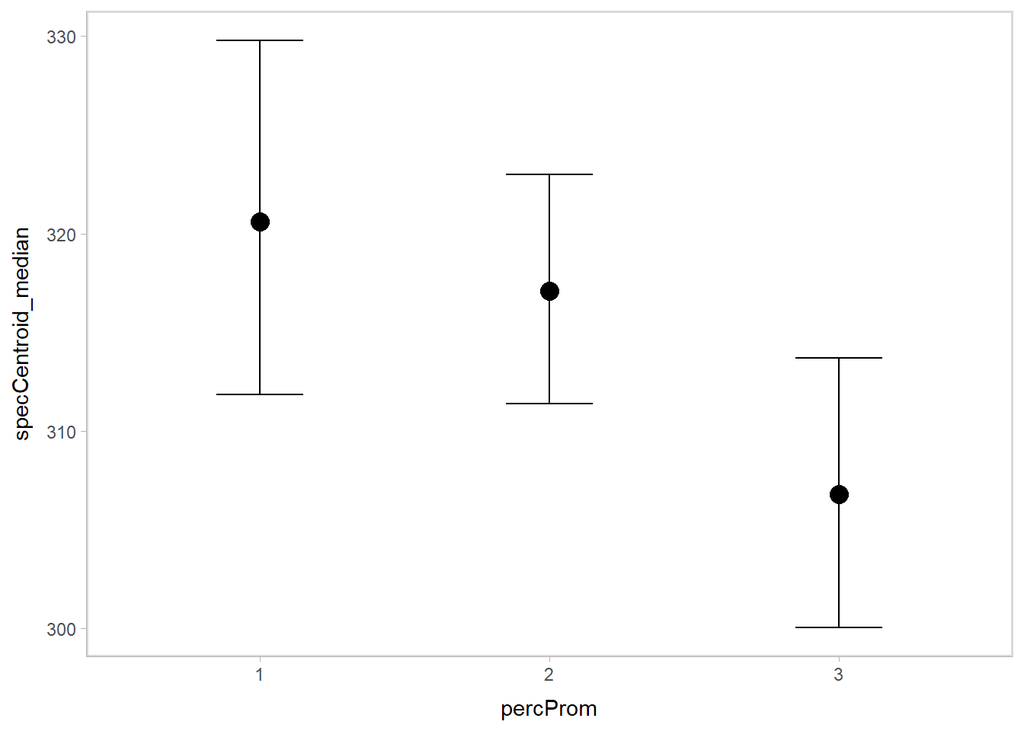

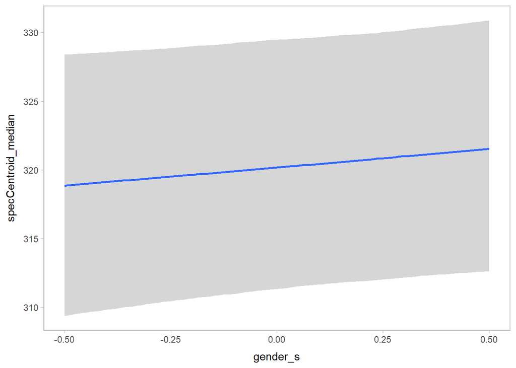

| percProm | specCentroid_median | gender_s | participant | cond__ | effect1__ | estimate__ | se__ | lower__ | upper__ |
| --- | --- | --- | --- | --- | --- | --- | --- | --- | --- |
| 1 | 316.7113 | 0.1565702 | NA | 1 | 1 | 320.5822 | 4.437600 | 311.8242 | 329.7984 |
| 2 | 316.7113 | 0.1565702 | NA | 1 | 2 | 317.0731 | 2.858932 | 311.3656 | 322.9819 |
| 3 | 316.7113 | 0.1565702 | NA | 1 | 3 | 306.8025 | 3.374229 | 300.0469 | 313.7018 |

Compare conditional effects to raw values.

| percProm | avg_specCentroid_median |
| --- | --- |
| 1 | 317.7988 |
| 2 | 317.6634 |
| 3 | 309.8666 |

```
##    Min. 1st Qu.  Median    Mean 3rd Qu.    Max.    NA's
##   217.1   291.6   314.2   316.7   340.7   421.8       1
```

##### 4.1.8.3.1 Effect comparison

```
##  percProm emmean lower.HPD upper.HPD
##  1           319       310       328
##  2           315       310       321
##  3           305       298       312
##
## Results are averaged over the levels of: gender_s
## Point estimate displayed: median
## HPD interval probability: 0.95
```

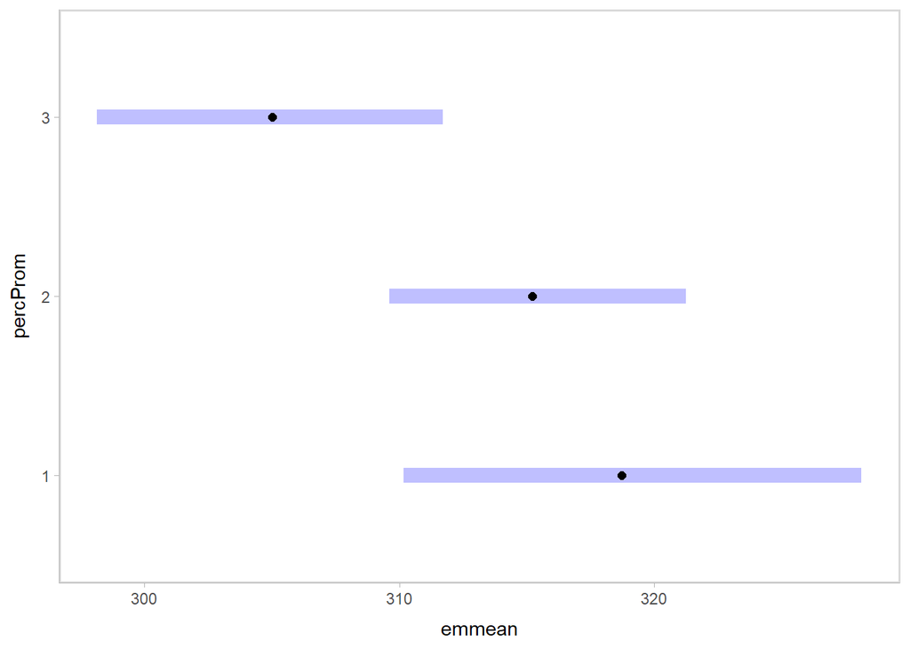

```
##  contrast              estimate lower.HPD upper.HPD
##  percProm1 - percProm2     3.53     -3.17      10.1
##  percProm1 - percProm3    13.74      4.87      21.8
##  percProm2 - percProm3    10.24      5.37      15.2
##
## Results are averaged over the levels of: gender_s
## Point estimate displayed: median
## HPD interval probability: 0.95
```

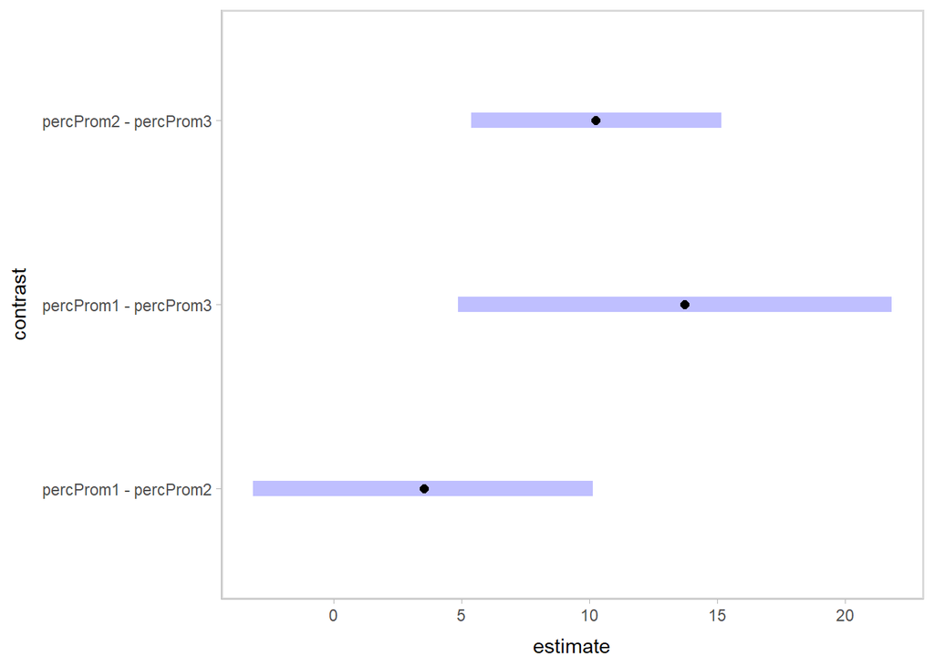

If the comparison includes 0, the contrast is not reliably different.

##### 4.1.8.3.2 Hypothesis testing

| Comparison | Estimate | Est.Error | CI.Lower | CI.Upper | Post.Prob | Star |
| --- | --- | --- | --- | --- | --- | --- |
| diff_1_2 | -3.538 | 3.384 | -10.271 | 3.069 | 85.69 |  |
| diff_1_3 | -13.768 | 4.300 | -22.378 | -5.382 | 99.93 | * |
| diff_2_3 | -10.229 | 2.484 | -15.088 | -5.263 | 100.00 | * |

- **diff_1_2:** Estimate = -3.54 [-10.3, 3.07], Posterior Probability = 85.7%; Weak evidence that `specCentroid_median` at `percProm2` is lower than at `percProm1`, but this difference is not conclusive.
- **diff_1_3:** Estimate = -13.8 [-22.4, -5.38], Posterior Probability = 99.9%; Strong evidence that `specCentroid_median` is lower at `percProm3` than at `percProm1`.
- **diff_2_3:** Estimate = -10.2 [-15.1, -5.26], Posterior Probability = 100%; Strong evidence that `specCentroid_median` is lower at `percProm3` than at `percProm2`.

**Overall Implications:** A trend is observed, where `specCentroid_median` decreases with perceived prominence levels, particularly between `percProm1` and `percProm3`.

##### 4.1.8.3.3 Plot fixef

Visualize the (non-)linearity of the effect with a violin plot of the posteriors for each prominence level and a GAMM overlaid on top.

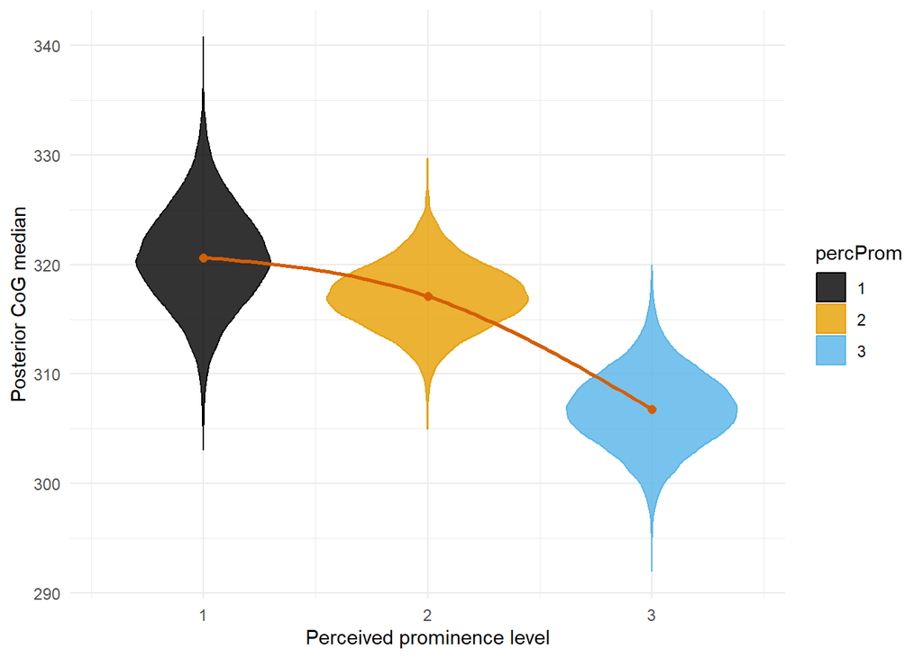

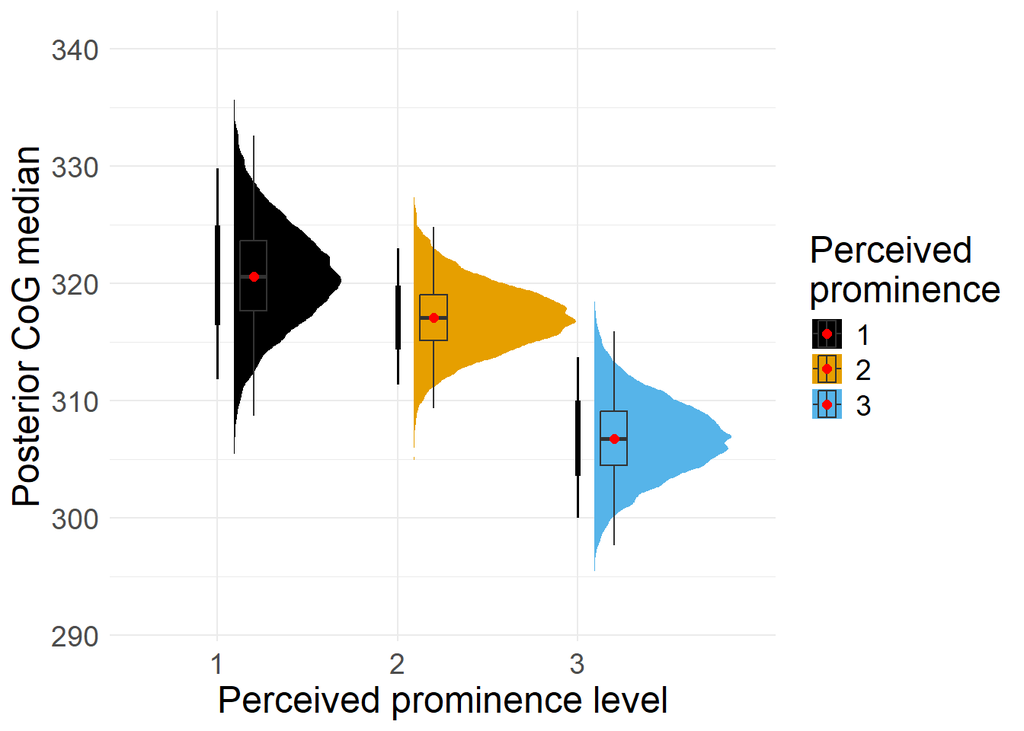

#### 4.1.8.4 Group-level effects

First, get a general overview.

| Random Effect | Estimate | Est.Error | Q2.5 | Q97.5 |
| --- | --- | --- | --- | --- |
| percProm1 | 0.07759334 | 0.011597374 | 0.05809484 | 0.10282429 |
| percProm2 | 0.05220644 | 0.007011965 | 0.04039119 | 0.06780153 |
| percProm3 | 0.05409062 | 0.009592851 | 0.03757628 | 0.07502874 |

- **percProm1:** Estimated SD = 0.078 (95% CrI: 0.058 to 0.103)
- **percProm2:** Estimated SD = 0.052 (95% CrI: 0.04 to 0.068)
- **percProm3:** Estimated SD = 0.054 (95% CrI: 0.038 to 0.075)

Variability remains moderate across levels, suggesting participant responses vary slightly based on perceived prominence levels.

Extract samples in interpretable units. Then, plot them so that we can see how each participant uses the levels of percProm.

| participant | percProm | gender_s | .row | .epred | .lower | .upper | .width | .point | .interval |
| --- | --- | --- | --- | --- | --- | --- | --- | --- | --- |
| 1 | 1 | 0.1563 | 1 | 289.7289 | 274.9514 | 305.2669 | 0.95 | median | qi |
| 1 | 2 | 0.1563 | 2 | 299.7610 | 291.8466 | 308.2897 | 0.95 | median | qi |
| 1 | 3 | 0.1563 | 3 | 291.3123 | 280.1019 | 302.6034 | 0.95 | median | qi |
| 2 | 1 | 0.1563 | 4 | 314.3034 | 297.6261 | 332.0809 | 0.95 | median | qi |
| 2 | 2 | 0.1563 | 5 | 303.2786 | 295.3800 | 311.2441 | 0.95 | median | qi |
| 2 | 3 | 0.1563 | 6 | 294.8257 | 283.4900 | 306.3498 | 0.95 | median | qi |
| 3 | 1 | 0.1563 | 7 | 330.2809 | 314.2137 | 347.6711 | 0.95 | median | qi |
| 3 | 2 | 0.1563 | 8 | 322.6608 | 314.7227 | 330.8513 | 0.95 | median | qi |
| 3 | 3 | 0.1563 | 9 | 307.2357 | 296.1007 | 317.6885 | 0.95 | median | qi |
| 4 | 1 | 0.1563 | 10 | 356.6235 | 340.3848 | 374.0374 | 0.95 | median | qi |

[output cut: 95 more lines]

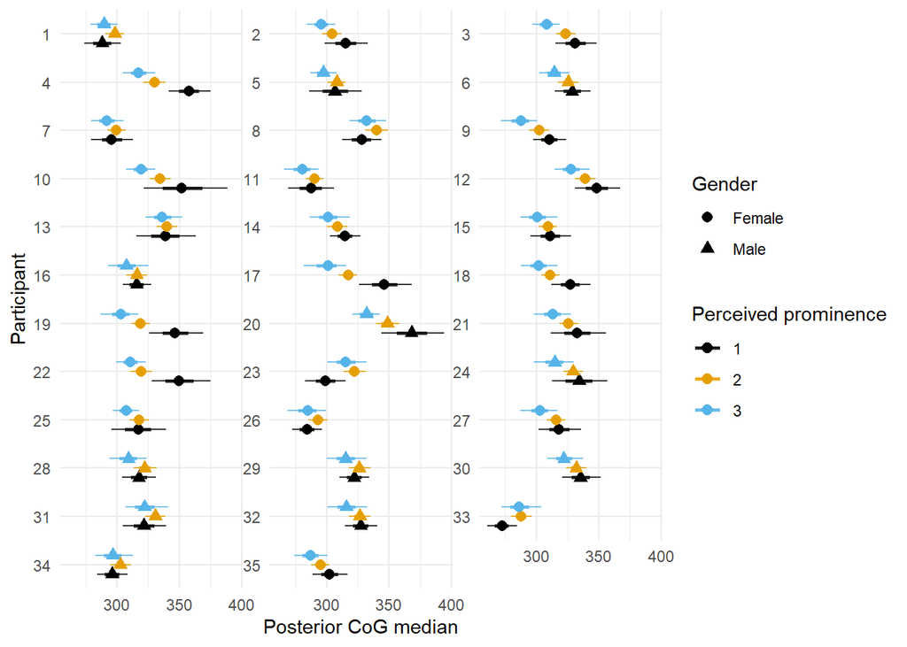

First, we extract individual draws. Here, if the CrI encompasses 0, the participant does not differ from the overall behavior on this percProm. Then, we plot random effects for each participant and percProm level on the model scale, representing deviations from the fixed effects.

| participant | percProm | r_participant | .lower | .upper | .width | .point | .interval |
| --- | --- | --- | --- | --- | --- | --- | --- |
| 1 | percProm1 | -0.1011923438 | -0.1594219600 | -0.045244913 | 0.95 | median | qi |
| 1 | percProm2 | -0.0561154061 | -0.0876904538 | -0.023235319 | 0.95 | median | qi |
| 1 | percProm3 | -0.0517026056 | -0.0943409036 | -0.010787632 | 0.95 | median | qi |
| 2 | percProm1 | -0.0199381993 | -0.0785416977 | 0.040532151 | 0.95 | median | qi |
| 2 | percProm2 | -0.0444023679 | -0.0764969769 | -0.013949869 | 0.95 | median | qi |
| 2 | percProm3 | -0.0397706462 | -0.0820917008 | 0.001877808 | 0.95 | median | qi |
| 3 | percProm1 | 0.0296805869 | -0.0257824792 | 0.086567999 | 0.95 | median | qi |
| 3 | percProm2 | 0.0173652540 | -0.0127064636 | 0.048070979 | 0.95 | median | qi |
| 3 | percProm3 | 0.0014404626 | -0.0395662918 | 0.039253141 | 0.95 | median | qi |
| 4 | percProm1 | 0.1063759234 | 0.0538116329 | 0.160315369 | 0.95 | median | qi |

[output cut: 95 more lines]

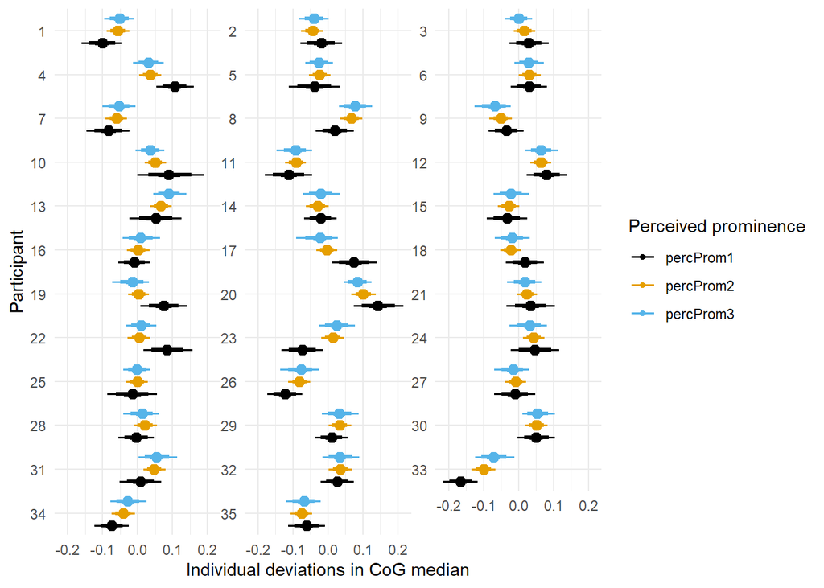

### 4.1.9 Duration (without silences)

#### 4.1.9.1 Priors

| prior | class | coef | group | resp | dpar | nlpar | lb | ub | source |
| --- | --- | --- | --- | --- | --- | --- | --- | --- | --- |
|  | b |  |  |  |  |  |  |  | default |
|  | b | gender_s |  |  |  |  |  |  | default |
|  | b | percProm1 |  |  |  |  |  |  | default |
|  | b | percProm2 |  |  |  |  |  |  | default |
|  | b | percProm3 |  |  |  |  |  |  | default |
| lkj(1) | cor |  |  |  |  |  |  |  | default |
|  | cor |  | participant |  |  |  |  |  | default |
| student_t(3, 0, 2.5) | sd |  |  |  |  |  | 0 |  | default |
|  | sd |  | participant |  |  |  |  |  | default |
|  | sd | percProm1 | participant |  |  |  |  |  | default |

[output cut: 3 more lines]

#### 4.1.9.2 Model

Calculate R².

```
##     Estimate  Est.Error      Q2.5     Q97.5
## R2 0.1999007 0.01466163 0.1713953 0.2290767
```

An R² of approximately 0.20 indicates a modest fit, with the model explaining about 20.0% of the variance in `duration_noSilence`. The credible interval (17.1% to 22.9%) indicates moderate certainty around this explanatory power.

#### 4.1.9.3 Fixed effects

Let’s check how it looks like.

```
##  Family: lognormal
##   Links: mu = identity; sigma = identity
## Formula: duration_noSilence ~ 0 + percProm + gender_s + (0 + percProm | participant)
##    Data: data_prepost_cat (Number of observations: 2245)
##   Draws: 4 chains, each with iter = 8000; warmup = 4000; thin = 1;
##          total post-warmup draws = 16000
##
## Multilevel Hyperparameters:
## ~participant (Number of levels: 35)
##                          Estimate Est.Error l-95% CI u-95% CI Rhat Bulk_ESS
## sd(percProm1)                0.16      0.03     0.11     0.23 1.00     7334
## sd(percProm2)                0.14      0.02     0.11     0.19 1.00     7138
## sd(percProm3)                0.18      0.03     0.12     0.25 1.00     8836
## cor(percProm1,percProm2)     0.66      0.15     0.32     0.89 1.00     4682
## cor(percProm1,percProm3)     0.63      0.19     0.19     0.93 1.00     5587
## cor(percProm2,percProm3)     0.79      0.12     0.48     0.97 1.00     7956
##                          Tail_ESS
## sd(percProm1)               10567
## sd(percProm2)               11384
## sd(percProm3)               11596
## cor(percProm1,percProm2)     7595
## cor(percProm1,percProm3)     7814
## cor(percProm2,percProm3)     9856
##
## Regression Coefficients:
##           Estimate Est.Error l-95% CI u-95% CI Rhat Bulk_ESS Tail_ESS
## percProm1     5.05      0.03     4.98     5.11 1.00     6212     9625
## percProm2     5.15      0.03     5.10     5.20 1.00     6246     9761
## percProm3     5.29      0.04     5.21     5.37 1.00     7375    11658
## gender_s      0.08      0.05     0.01     0.18 1.00     6689     7514
##
## Further Distributional Parameters:
##       Estimate Est.Error l-95% CI u-95% CI Rhat Bulk_ESS Tail_ESS
## sigma     0.32      0.00     0.31     0.33 1.00    29897    11437
##
## Draws were sampled using sampling(NUTS). For each parameter, Bulk_ESS
## and Tail_ESS are effective sample size measures, and Rhat is the potential
## scale reduction factor on split chains (at convergence, Rhat = 1).
```

```
##             Estimate Est.Error       Q2.5      Q97.5
## percProm1 155.877398  1.034254 145.868565 166.436640
## percProm2 172.523441  1.027185 163.650036 181.817854
## percProm3 198.881462  1.040217 183.619247 214.274873
## gender_s    1.083926  1.046648   1.006463   1.194102
```

It shows a stable increase from 1 to 3.

Diagnostic plots.

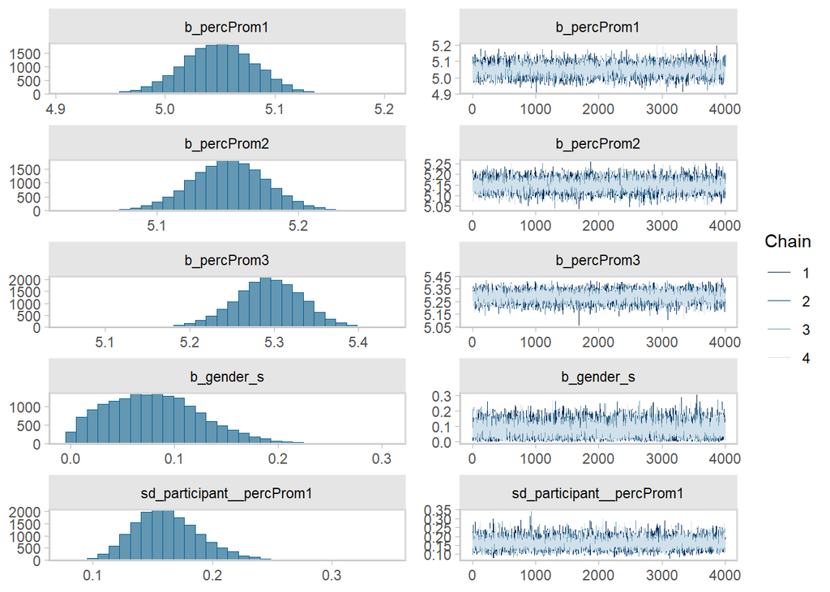

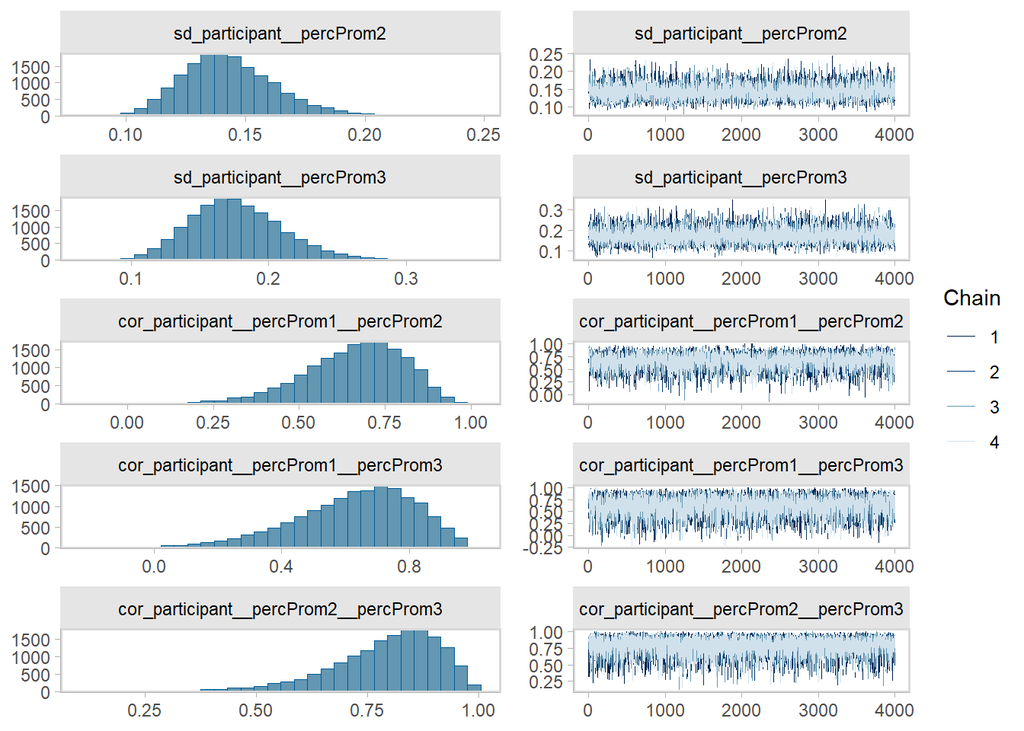

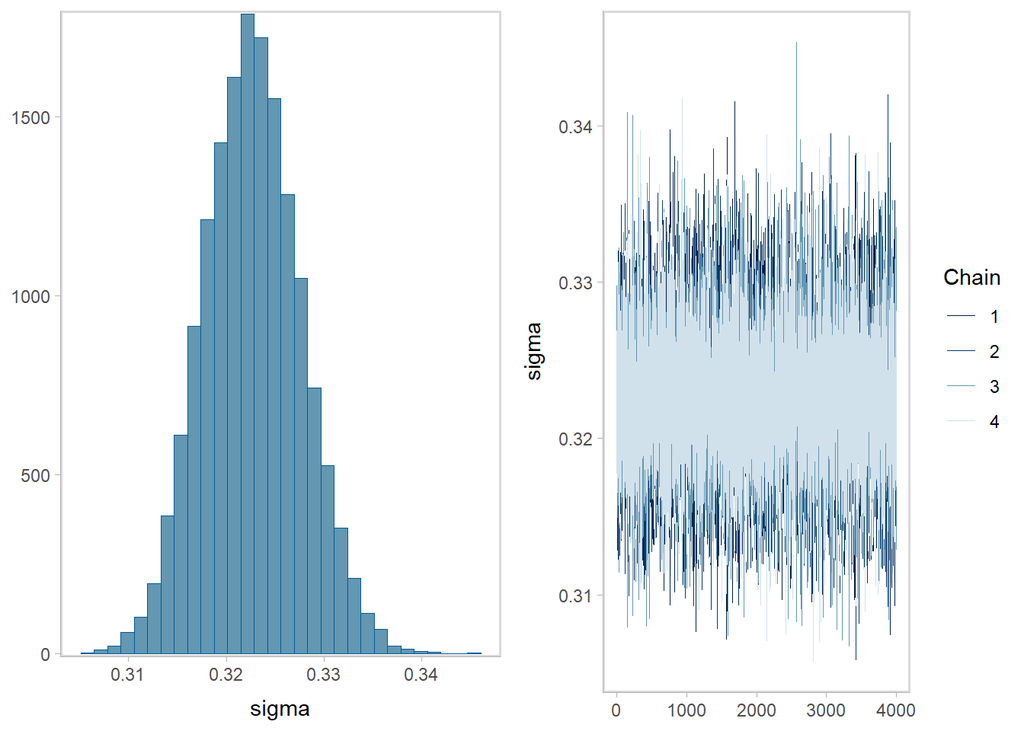

Posterior predictive check.

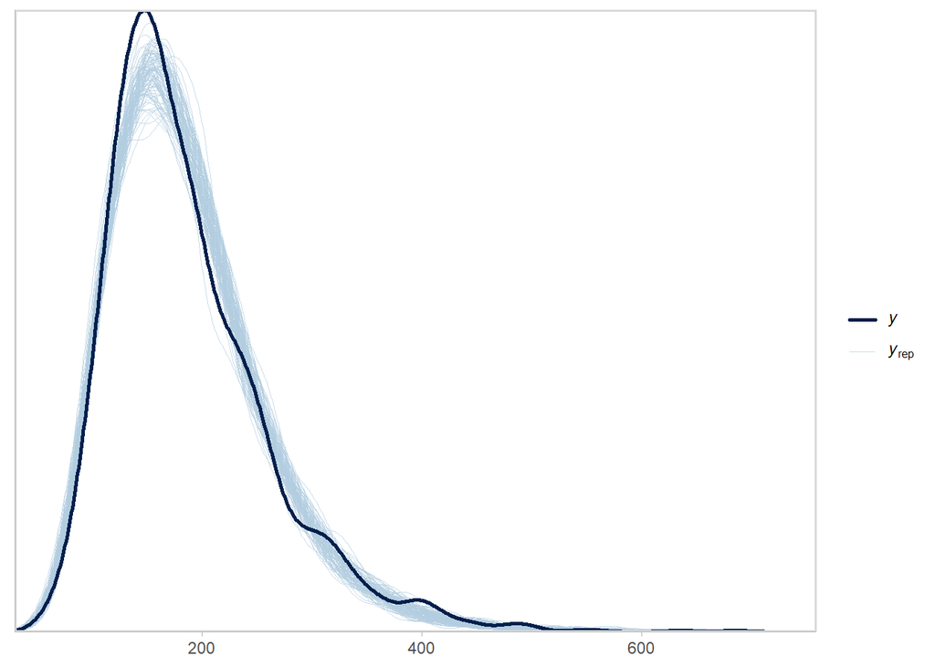

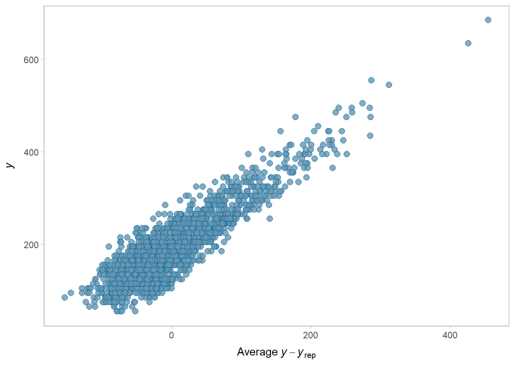

Extract samples.

| variable | mean | median | sd | mad | q5 | q95 | rhat | ess_bulk | ess_tail |
| --- | --- | --- | --- | --- | --- | --- | --- | --- | --- |
| b_percProm1 | 5.049070 | 5.04904371 | 0.03368029 | 0.03303795 | 4.99372856 | 5.1041052 | 1.000136 | 6211.683 | 9625.406 |
| b_percProm2 | 5.150533 | 5.15063168 | 0.02682212 | 0.02657764 | 5.10596829 | 5.1944050 | 1.000429 | 6246.126 | 9760.590 |
| b_percProm3 | 5.292709 | 5.29327880 | 0.03942972 | 0.03901758 | 5.22594488 | 5.3553875 | 1.000464 | 7374.697 | 11658.127 |
| b_gender_s | 0.080590 | 0.07787947 | 0.04559233 | 0.04793561 | 0.01248947 | 0.1615832 | 1.000358 | 6688.886 | 7514.203 |
| exp_b_percProm1 | 155.965858 | 155.87333332 | 5.25732504 | 5.14706969 | 147.48530772 | 164.6966372 | 1.000136 | 6211.683 | 9625.406 |
| exp_b_percProm2 | 172.585507 | 172.54044638 | 4.63004958 | 4.57859894 | 165.00376415 | 180.2608535 | 1.000429 | 6246.126 | 9760.590 |
| exp_b_percProm3 | 199.035754 | 198.99482063 | 7.82392263 | 7.77418315 | 186.03686960 | 211.7460105 | 1.000464 | 7374.697 | 11658.127 |

Check conditional effect.

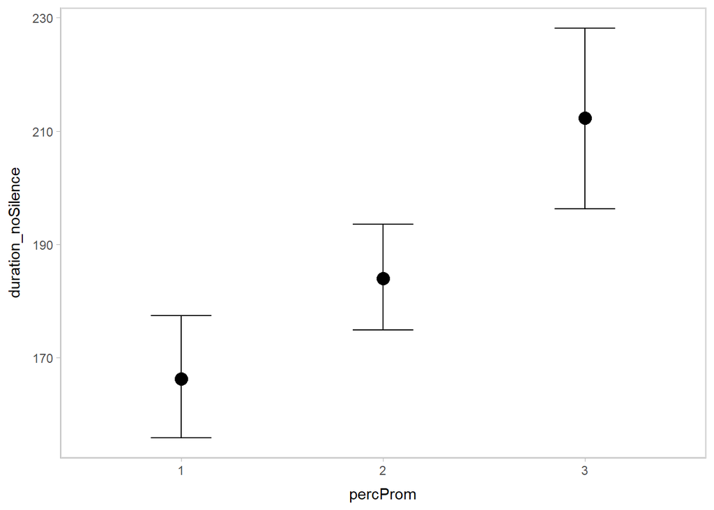

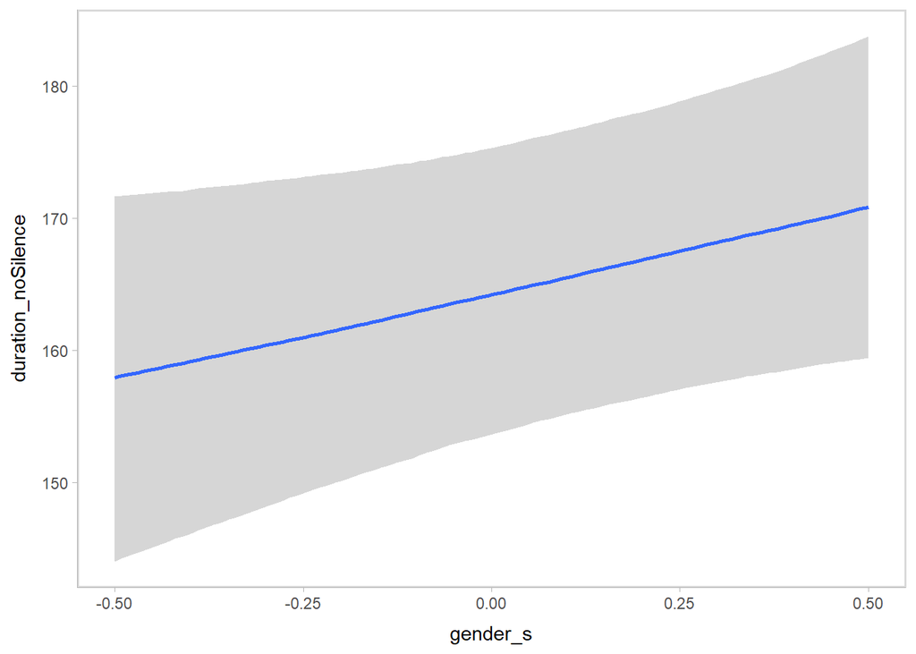

| percProm | duration_noSilence | gender_s | participant | cond__ | effect1__ | estimate__ | se__ | lower__ | upper__ |
| --- | --- | --- | --- | --- | --- | --- | --- | --- | --- |
| 1 | 187.6904 | 0.1565702 | NA | 1 | 1 | 166.2788 | 5.391334 | 155.9082 | 177.4697 |
| 2 | 187.6904 | 0.1565702 | NA | 1 | 2 | 184.0200 | 4.724667 | 174.9179 | 193.5966 |
| 3 | 187.6904 | 0.1565702 | NA | 1 | 3 | 212.2771 | 8.146969 | 196.2781 | 228.1982 |

Compare conditional effects to raw values.

| percProm | avg_duration_noSilence |
| --- | --- |
| 1 | 164.7462 |
| 2 | 186.2293 |
| 3 | 228.0249 |

```
##    Min. 1st Qu.  Median    Mean 3rd Qu.    Max.    NA's
##    55.0   135.0   175.0   187.7   225.0   685.0       1
```

##### 4.1.9.3.1 Effect comparison

```
##  percProm emmean lower.HPD upper.HPD
##  1           156       146       166
##  2           173       164       182
##  3           199       184       214
##
## Results are averaged over the levels of: gender_s
## Point estimate displayed: median
## HPD interval probability: 0.95
```

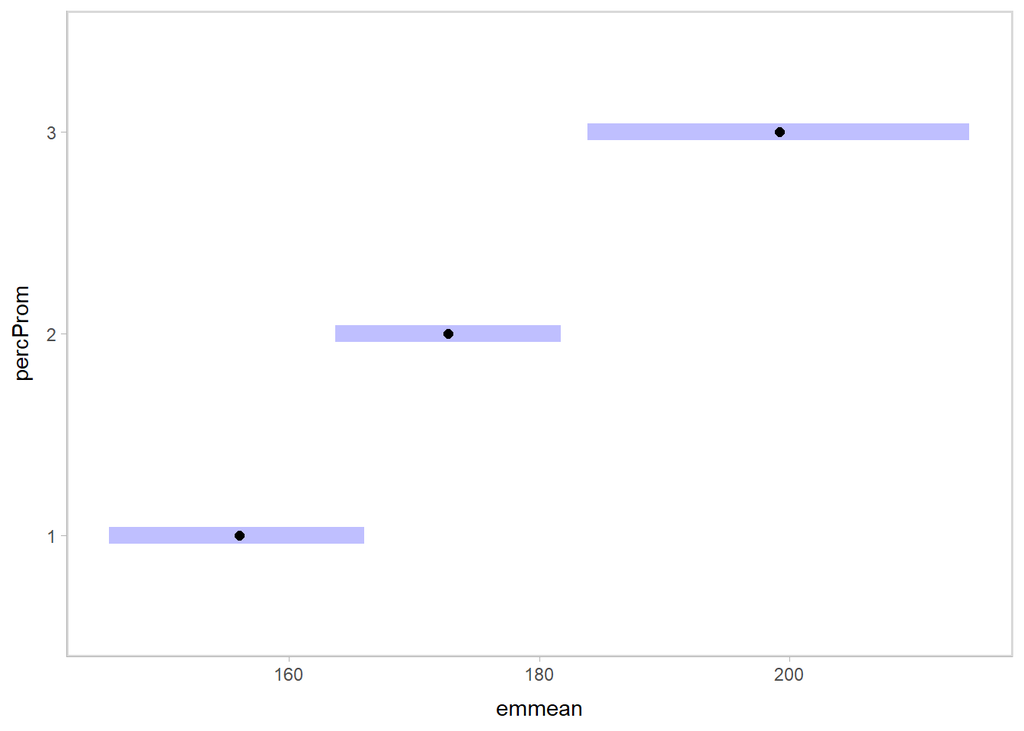

```
##  contrast              estimate lower.HPD upper.HPD
##  percProm1 - percProm2    -16.6     -25.7     -6.98
##  percProm1 - percProm3    -43.2     -57.9    -29.43
##  percProm2 - percProm3    -26.5     -38.4    -14.11
##
## Results are averaged over the levels of: gender_s
## Point estimate displayed: median
## HPD interval probability: 0.95
```

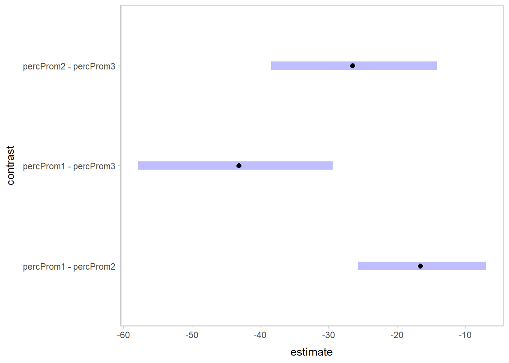

If the comparison includes 0, the contrast is not reliably different.

##### 4.1.9.3.2 Hypothesis testing

| Comparison | Estimate | Est.Error | CI.Lower | CI.Upper | Post.Prob | Star |
| --- | --- | --- | --- | --- | --- | --- |
| diff_1_2 | 16.62 | 4.77 | 7.289 | 26.048 | 99.94 | * |
| diff_1_3 | 43.07 | 7.21 | 28.994 | 57.595 | 100.00 | * |
| diff_2_3 | 26.45 | 6.17 | 14.351 | 38.656 | 100.00 | * |

- **diff_1_2:** Estimate = 16.6 [7.29, 26.0], Posterior Probability = 99.9%; Strong evidence that `duration_noSilence` increases from `percProm1` to `percProm2`.
- **diff_1_3:** Estimate = 43.1 [29.0, 57.6], Posterior Probability = 100%; Strong evidence that `duration_noSilence` increases from `percProm1` to `percProm3`.
- **diff_2_3:** Estimate = 26.4 [14.4, 38.7], Posterior Probability = 100%; Strong evidence that `duration_noSilence` increases from `percProm2` to `percProm3`.

**Overall Implications:** `duration_noSilence` tends to increase as perceived prominence levels increase, with consistent evidence supporting this trend.

##### 4.1.9.3.3 Plot fixef

Visualize the (non-)linearity of the effect with a violin plot of the posteriors for each prominence level and a GAMM overlaid on top.

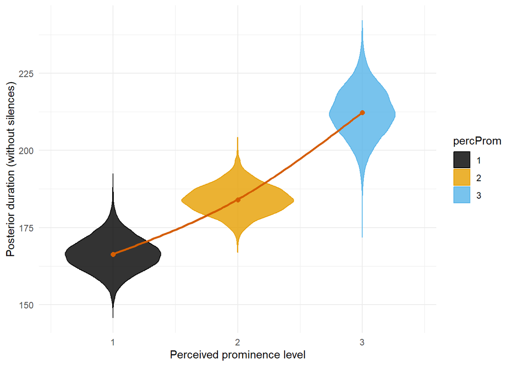

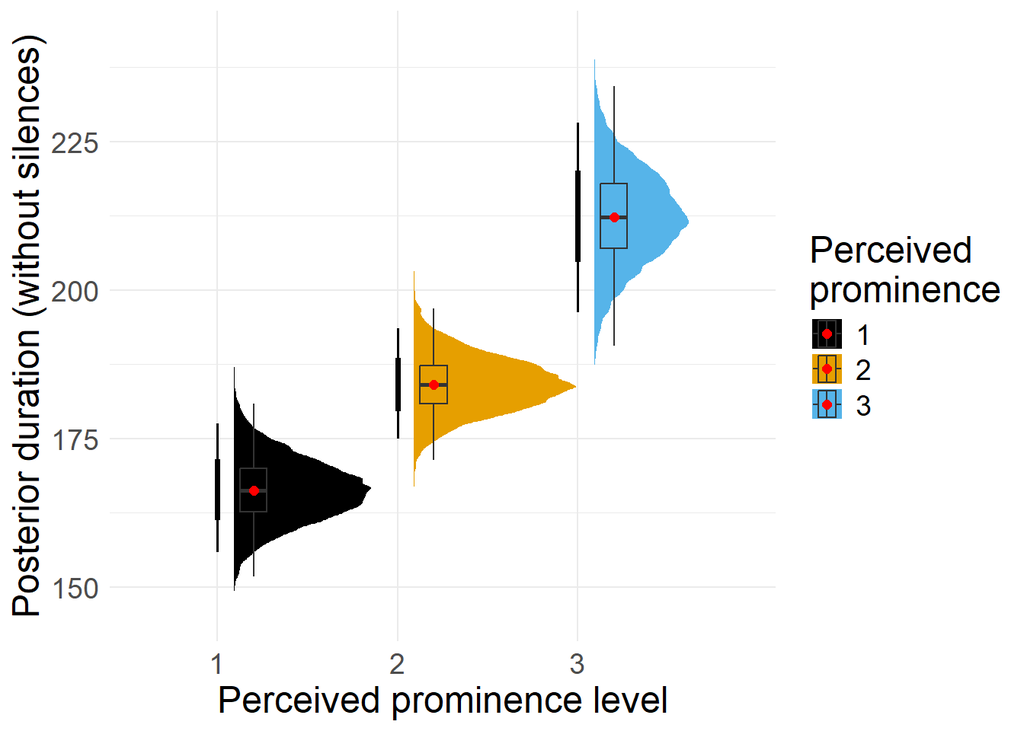

#### 4.1.9.4 Group-level effects

First, get a general overview.

| Random Effect | Estimate | Est.Error | Q2.5 | Q97.5 |
| --- | --- | --- | --- | --- |
| percProm1 | 0.1624405 | 0.02875523 | 0.1134261 | 0.2256119 |
| percProm2 | 0.1433209 | 0.01986800 | 0.1094878 | 0.1875839 |
| percProm3 | 0.1767903 | 0.03443277 | 0.1165601 | 0.2513264 |

- **percProm1:** Estimated SD = 0.162 (95% CrI: 0.113 to 0.226)
- **percProm2:** Estimated SD = 0.143 (95% CrI: 0.109 to 0.188)
- **percProm3:** Estimated SD = 0.177 (95% CrI: 0.117 to 0.251)

Variability shows modest participant-level differences across perceived prominence levels.

Extract samples in interpretable units. Then, plot them so that we can see how each participant uses the levels of percProm.

| participant | percProm | gender_s | .row | .epred | .lower | .upper | .width | .point | .interval |
| --- | --- | --- | --- | --- | --- | --- | --- | --- | --- |
| 1 | 1 | 0.1563 | 1 | 216.5397 | 182.5867 | 261.4577 | 0.95 | median | qi |
| 1 | 2 | 0.1563 | 2 | 200.3319 | 180.4267 | 222.8077 | 0.95 | median | qi |
| 1 | 3 | 0.1563 | 3 | 258.3400 | 221.0943 | 304.1611 | 0.95 | median | qi |
| 2 | 1 | 0.1563 | 4 | 154.9288 | 129.4870 | 181.8518 | 0.95 | median | qi |
| 2 | 2 | 0.1563 | 5 | 200.0012 | 182.3092 | 219.5732 | 0.95 | median | qi |
| 2 | 3 | 0.1563 | 6 | 222.7959 | 192.4091 | 257.1068 | 0.95 | median | qi |
| 3 | 1 | 0.1563 | 7 | 171.7856 | 146.8041 | 199.1794 | 0.95 | median | qi |
| 3 | 2 | 0.1563 | 8 | 204.5609 | 187.2825 | 223.9582 | 0.95 | median | qi |
| 3 | 3 | 0.1563 | 9 | 243.7718 | 215.4854 | 277.5923 | 0.95 | median | qi |
| 4 | 1 | 0.1563 | 10 | 175.7188 | 152.3702 | 202.6218 | 0.95 | median | qi |

[output cut: 95 more lines]

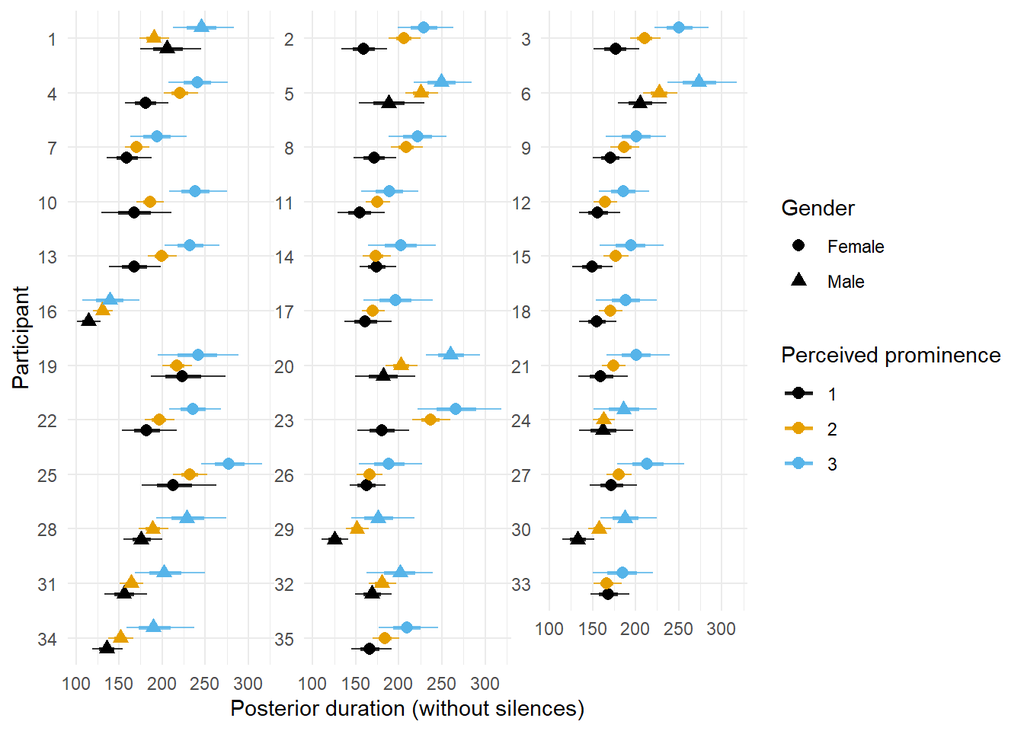

First, we extract individual draws. Here, if the CrI encompasses 0, the participant does not differ from the overall behavior on this percProm. Then, we plot random effects for each participant and percProm level on the model scale, representing deviations from the fixed effects.

| participant | percProm | r_participant | .lower | .upper | .width | .point | .interval |
| --- | --- | --- | --- | --- | --- | --- | --- |
| 1 | percProm1 | 0.263554290 | 0.091750660 | 0.4568284626 | 0.95 | median | qi |
| 1 | percProm2 | 0.085225734 | -0.030873271 | 0.2005047874 | 0.95 | median | qi |
| 1 | percProm3 | 0.196536954 | 0.028543107 | 0.3781788923 | 0.95 | median | qi |
| 2 | percProm1 | -0.070357030 | -0.255746384 | 0.0907396185 | 0.95 | median | qi |
| 2 | percProm2 | 0.083127524 | -0.018819421 | 0.1855535667 | 0.95 | median | qi |
| 2 | percProm3 | 0.048053933 | -0.106337055 | 0.2063572439 | 0.95 | median | qi |
| 3 | percProm1 | 0.032145270 | -0.130450235 | 0.1848578230 | 0.95 | median | qi |
| 3 | percProm2 | 0.105690291 | 0.005196978 | 0.2083994079 | 0.95 | median | qi |
| 3 | percProm3 | 0.138152840 | 0.003944097 | 0.2856749060 | 0.95 | median | qi |
| 4 | percProm1 | 0.055446678 | -0.094208105 | 0.2054902819 | 0.95 | median | qi |

[output cut: 95 more lines]

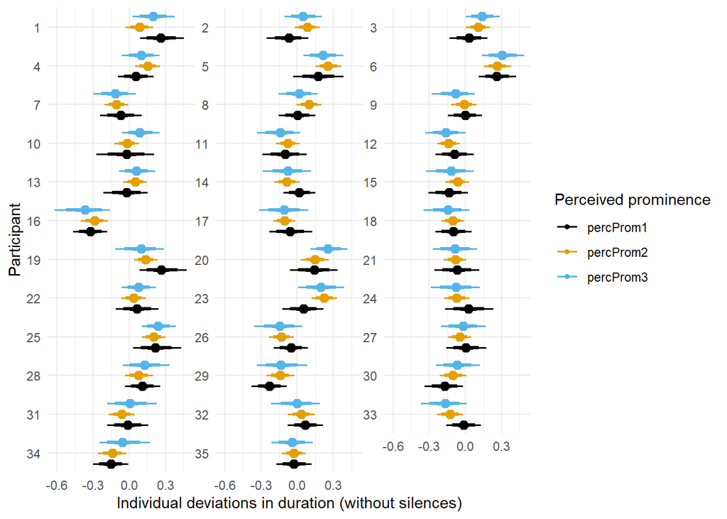

### 4.1.10 Duration (pretonic)

#### 4.1.10.1 Priors

| prior | class | coef | group | resp | dpar | nlpar | lb | ub | source |
| --- | --- | --- | --- | --- | --- | --- | --- | --- | --- |
|  | b |  |  |  |  |  |  |  | default |
|  | b | gender_s |  |  |  |  |  |  | default |
|  | b | percProm1 |  |  |  |  |  |  | default |
|  | b | percProm2 |  |  |  |  |  |  | default |
|  | b | percProm3 |  |  |  |  |  |  | default |
| lkj(1) | cor |  |  |  |  |  |  |  | default |
|  | cor |  | participant |  |  |  |  |  | default |
| student_t(3, 0, 2.5) | sd |  |  |  |  |  | 0 |  | default |
|  | sd |  | participant |  |  |  |  |  | default |
|  | sd | percProm1 | participant |  |  |  |  |  | default |

[output cut: 3 more lines]

#### 4.1.10.2 Model

Calculate R².

```
##     Estimate Est.Error       Q2.5     Q97.5
## R2 0.1239293 0.0153715 0.09510713 0.1551957
```

An R² of approximately 0.12 indicates a relatively low fit, suggesting the model explains around 12.4% of the variance in `durationPre`. The 95% credible interval (9.5% to 15.5%) indicates some uncertainty in the explanatory power of the model.

#### 4.1.10.3 Fixed effects

Let’s check how it looks like.

```
##  Family: lognormal
##   Links: mu = identity; sigma = identity
## Formula: durationPre ~ 0 + percProm + gender_s + (0 + percProm | participant)
##    Data: data_prepost_cat (Number of observations: 2063)
##   Draws: 4 chains, each with iter = 8000; warmup = 4000; thin = 1;
##          total post-warmup draws = 16000
##
## Multilevel Hyperparameters:
## ~participant (Number of levels: 35)
##                          Estimate Est.Error l-95% CI u-95% CI Rhat Bulk_ESS
## sd(percProm1)                0.13      0.03     0.08     0.20 1.00     5841
## sd(percProm2)                0.10      0.02     0.07     0.13 1.00     7318
## sd(percProm3)                0.22      0.04     0.15     0.30 1.00     7764
## cor(percProm1,percProm2)     0.72      0.17     0.30     0.97 1.00     2783
## cor(percProm1,percProm3)     0.50      0.25    -0.04     0.90 1.00     2691
## cor(percProm2,percProm3)     0.83      0.12     0.53     0.98 1.00     7378
##                          Tail_ESS
## sd(percProm1)                9488
## sd(percProm2)               10653
## sd(percProm3)               10926
## cor(percProm1,percProm2)     5667
## cor(percProm1,percProm3)     4202
## cor(percProm2,percProm3)    11626
##
## Regression Coefficients:
##           Estimate Est.Error l-95% CI u-95% CI Rhat Bulk_ESS Tail_ESS
## percProm1     4.91      0.03     4.84     4.97 1.00     6898     9925
## percProm2     4.98      0.02     4.94     5.02 1.00     6342    10154
## percProm3     5.13      0.05     5.04     5.22 1.00     7834    10167
## gender_s      0.06      0.03     0.01     0.14 1.00     6377     5080
##
## Further Distributional Parameters:
##       Estimate Est.Error l-95% CI u-95% CI Rhat Bulk_ESS Tail_ESS
## sigma     0.38      0.01     0.37     0.39 1.00    23572    11765
##
## Draws were sampled using sampling(NUTS). For each parameter, Bulk_ESS
## and Tail_ESS are effective sample size measures, and Rhat is the potential
## scale reduction factor on split chains (at convergence, Rhat = 1).
```

```
##             Estimate Est.Error       Q2.5      Q97.5
## percProm1 135.038298  1.033495 126.611126 144.033299
## percProm2 146.197507  1.020698 140.468609 152.149767
## percProm3 168.879341  1.047879 153.745826 184.676868
## gender_s    1.066978  1.035397   1.006147   1.147767
```

It shows a stable increase from 1 to 3.

Diagnostic plots.

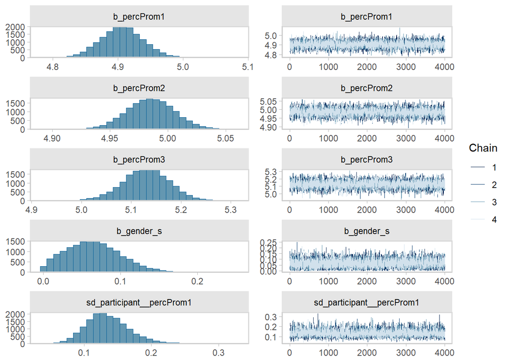

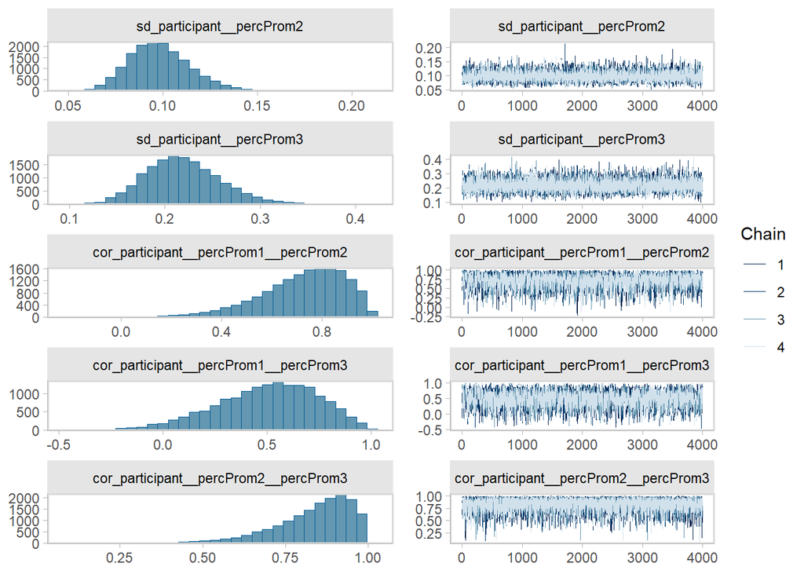

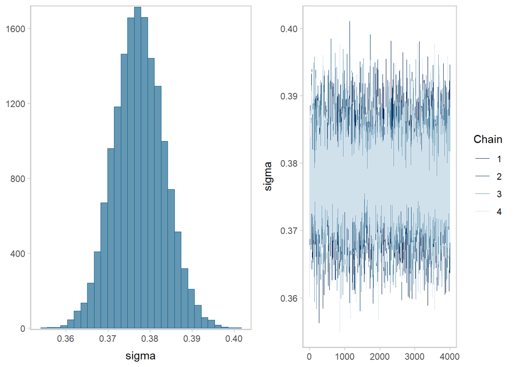

Posterior predictive check.

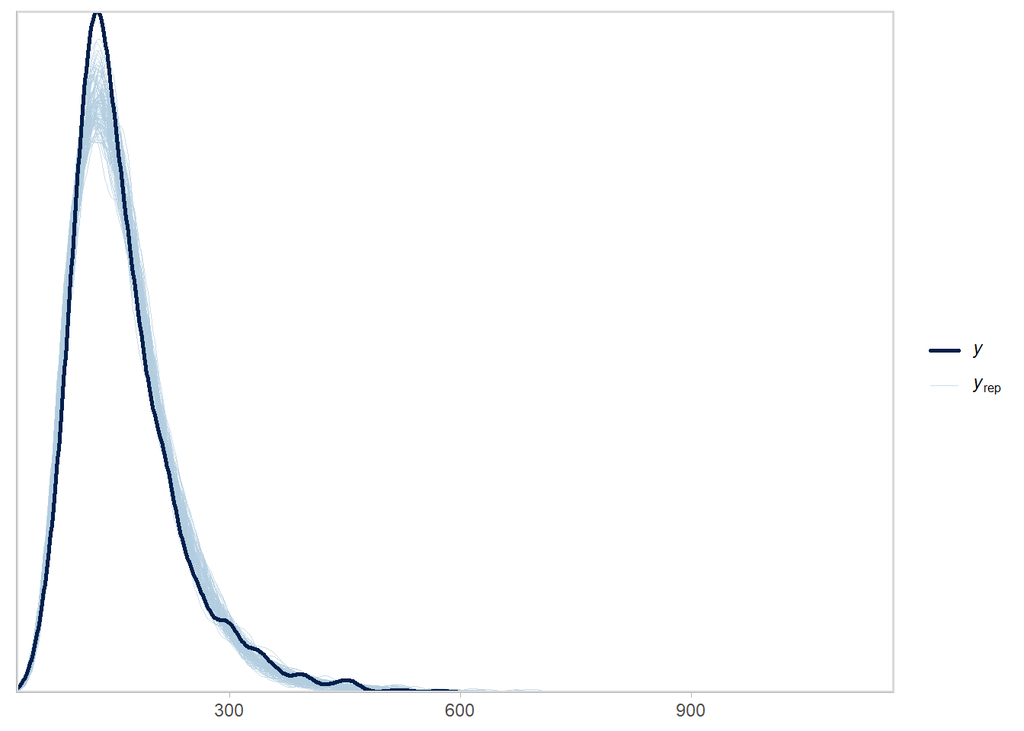

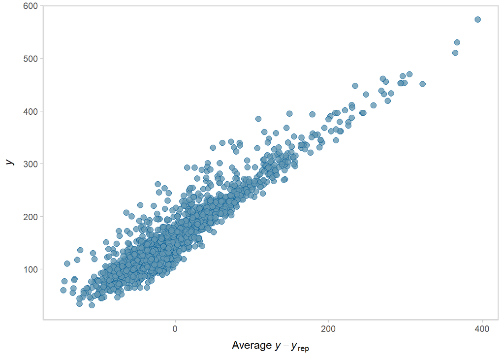

Extract samples.

| variable | mean | median | sd | mad | q5 | q95 | rhat | ess_bulk | ess_tail |
| --- | --- | --- | --- | --- | --- | --- | --- | --- | --- |
| b_percProm1 | 4.90555843 | 4.90532939 | 0.03294661 | 0.03218590 | 4.85214310 | 4.9595229 | 1.000476 | 6898.130 | 9925.346 |
| b_percProm2 | 4.98495850 | 4.98499438 | 0.02048685 | 0.02042994 | 4.95109373 | 5.0182621 | 1.000184 | 6342.018 | 10154.351 |
| b_percProm3 | 5.12918450 | 5.13000387 | 0.04676822 | 0.04608778 | 5.05032255 | 5.2036704 | 1.000201 | 7834.102 | 10167.490 |
| b_gender_s | 0.06483035 | 0.06298618 | 0.03478451 | 0.03655010 | 0.01135399 | 0.1249941 | 1.000361 | 6376.949 | 5080.296 |
| exp_b_percProm1 | 135.11161477 | 135.00737254 | 4.45384807 | 4.35259250 | 128.01444416 | 142.5257740 | 1.000476 | 6898.130 | 9925.346 |
| exp_b_percProm2 | 146.22818488 | 146.20275364 | 2.99551022 | 2.98700268 | 141.32945587 | 151.1483975 | 1.000184 | 6342.018 | 10154.351 |
| exp_b_percProm3 | 169.06377977 | 169.01777224 | 7.88961738 | 7.78124358 | 156.07279688 | 181.9388071 | 1.000192 | 7834.102 | 10167.490 |

Check conditional effect.

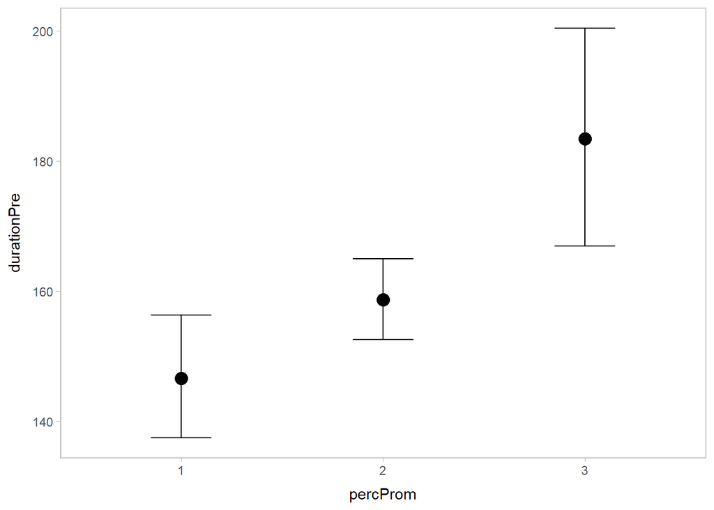

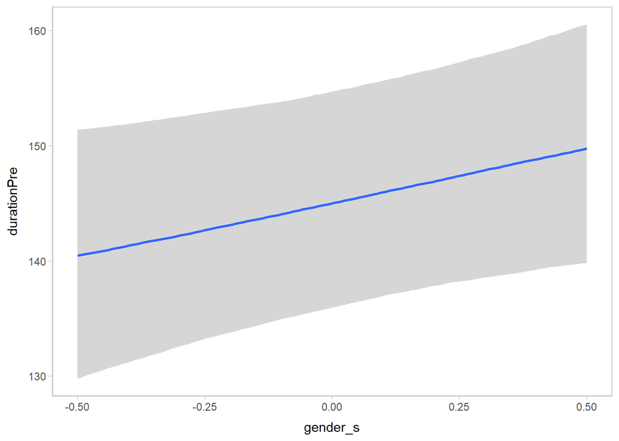

| percProm | durationPre | gender_s | participant | cond__ | effect1__ | estimate__ | se__ | lower__ | upper__ |
| --- | --- | --- | --- | --- | --- | --- | --- | --- | --- |
| 1 | 161.7092 | 0.1665051 | NA | 1 | 1 | 146.5900 | 4.695602 | 137.5229 | 156.3532 |
| 2 | 161.7092 | 0.1665051 | NA | 1 | 2 | 158.6846 | 3.109543 | 152.5972 | 165.0264 |
| 3 | 161.7092 | 0.1665051 | NA | 1 | 3 | 183.4578 | 8.441102 | 166.9833 | 200.4337 |

Compare conditional effects to raw values.

| percProm | avg_durationPre |
| --- | --- |
| 1 | 146.3031 |
| 2 | 159.5060 |
| 3 | 194.7269 |

```
##    Min. 1st Qu.  Median    Mean 3rd Qu.    Max.    NA's
##    31.0   116.0   146.0   161.7   191.0   573.0     183
```

##### 4.1.10.3.1 Effect comparison

```
##  percProm emmean lower.HPD upper.HPD
##  1           135       126       144
##  2           146       141       152
##  3           169       154       185
##
## Results are averaged over the levels of: gender_s
## Point estimate displayed: median
## HPD interval probability: 0.95
```

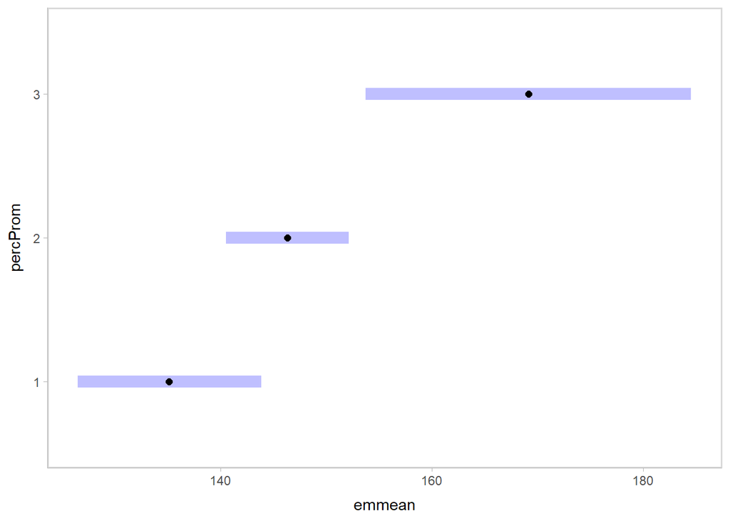

```
##  contrast              estimate lower.HPD upper.HPD
##  percProm1 - percProm2    -11.1     -18.9     -2.89
##  percProm1 - percProm3    -34.0     -49.1    -18.65
##  percProm2 - percProm3    -22.8     -35.9     -9.95
##
## Results are averaged over the levels of: gender_s
## Point estimate displayed: median
## HPD interval probability: 0.95
```

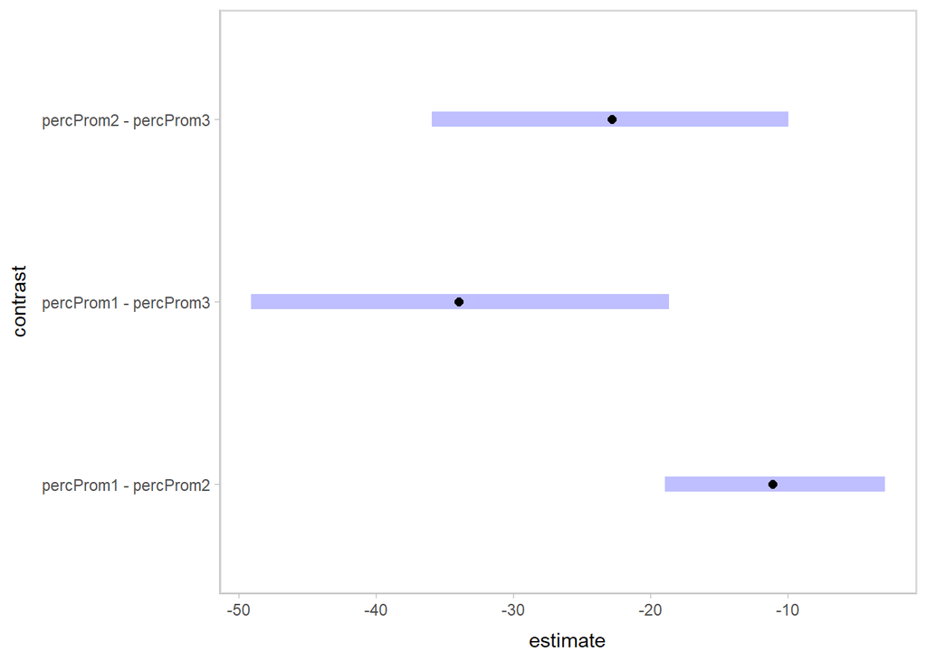

If the comparison includes 0, the contrast is not reliably different.